# **Used Cars Price Prediction**

# **Solution by: 'Femi Bolarinwa**

### Context

There is a huge demand for used cars in the Indian Market today. As sales of new cars have slowed down in the recent past, the pre-owned car market has continued to grow over the past few years and is now larger than the new car market. Cars4U is a budding tech start-up that aims to find footholes in this market. In 2018-19, while new car sales were recorded at 3.6 million units, around 4 million second-hand cars were bought and sold. There is a slowdown in new car sales and that could mean that the demand is shifting towards the pre-owned market. In fact, some car owners replace their old vehicles with pre-owned cars instead of buying a new automobile. Unlike new cars, where price and supply are fairly deterministic and managed by OEMs (Original Equipment Manufacturer / except for dealership level discounts which come into play only in the last stage of the customer journey), the used car market is a very different beast, with large uncertainties in both pricing and supply. Several factors, including mileage, brand, model, year, etc. can influence the actual worth of a car. From the perspective of a seller, it is not an easy task to set the correct price of a used car. Keeping this in mind, the pricing scheme of these used cars becomes important in order to grow in the market.

### Objective

Come up with a pricing model that can effectively predict the price of used cars and can help the business in devising profitable strategies using differential pricing.

### **Data Dictionary**

**S.No.** : Serial Number

**Name** : Name of the car which includes Brand name and Model name

**Location** : The location in which the car is being sold or is available for purchase (Cities)

**Year** : Manufacturing year of the car

**Kilometers_driven** : The total kilometers driven in the car by the previous owner(s) in KM

**Fuel_Type** : The type of fuel used by the car (Petrol, Diesel, Electric, CNG, LPG)

**Transmission** : The type of transmission used by the car (Automatic / Manual)

**Owner** : Type of ownership

**Mileage** : The standard mileage offered by the car company in kmpl or km/kg

**Engine** : The displacement volume of the engine in CC

**Power** : The maximum power of the engine in bhp

**Seats** : The number of seats in the car

**New_Price** : The price of a new car of the same model in INR 100,000

**Price** : The price of the used car in INR 100,000 (**Target Variable**)

## **Solution Notebook Content Overview:**

- **Libraries importation**
- **Data Overview**
- **Exploratory Data Analysis (EDA)**
- **Feature Engineering**
- **Data pre-processing**
- **Modelling**
  - **Linear Regression**
    - **Cross Validation and Evaluation**
    - **Verifying Assumptions**
  - **Regularization Techniques**
    - Ridge Regression
    - Lasso Regression
  - **XGBoost Regressor**
  - **Tree-based models**
    - Decision Tree
    - Random Forest
    - Hyper-parameter tuning of tree-based models (GridSearchCV)
    - Feature Importances
- **Conclusion, Business Insights and Recommendation**

### **Libraries Importation**

```python
#Libraries for data manipulation
import numpy as np               #array manipulation
import pandas as pd              #dataframe manipulation

# Removing the limit for the number of displayed columns
pd.set_option("display.max_columns", None)
# Setting the limit for the number of displayed rows
pd.set_option("display.max_rows", 200)
# setting the precision of floating numbers to 3 decimal points
pd.set_option("display.float_format", lambda x: "%.3f" % x)

#Libraries for data visualization
import matplotlib.pyplot as plt
import seaborn as sns

#To suppress warning
import warnings
warnings.filterwarnings("ignore")

#libraries for data pre-processing and tuning
from sklearn.preprocessing import MinMaxScaler, StandardScaler
from sklearn.model_selection import train_test_split, cross_val_score, KFold, GridSearchCV

#Libraries for linear modeling
from sklearn.linear_model import LinearRegression, Ridge, Lasso, ElasticNet

#Libraries for tree-based and ensemble modeling
from sklearn import tree
from sklearn.tree import DecisionTreeRegressor
from sklearn.ensemble import RandomForestRegressor,BaggingRegressor, AdaBoostRegressor, GradientBoostingRegressor

#Library for Extreme Gradient Boost modeling
from xgboost import XGBRegressor

# Libraries for model performance evaluation
from sklearn.metrics import make_scorer,mean_squared_error, r2_score, mean_absolute_error

#StatsModel Libraries for modeling
import statsmodels.api as sm
import statsmodels.stats.api as sms
from statsmodels.tools.tools import add_constant
from statsmodels.stats.outliers_influence import variance_inflation_factor
from statsmodels.tools.sm_exceptions import ConvergenceWarning
warnings.simplefilter("ignore", ConvergenceWarning)

#To perform goldfeldquandt test for homoscedasticity/heteroscedasticity
from statsmodels.stats.diagnostic import het_white
from statsmodels.compat import lzip

#Library for q-q plot to check normality of residuals
import pylab
import scipy.stats as stats
```

### **Loading dataset**

```python
dataframe = pd.read_csv("used_cars.csv")
```

```python
data = dataframe.copy() #preserving the original version of the loaded dataset
```

## Data Overview

```python
data.head() #viewing first 5 rows to ensure the intended dataset has been loaded
```

|  | S.No. | Name | Location | Year | Kilometers_Driven | Fuel_Type | Transmission | Owner_Type | Mileage | Engine | Power | Seats | New_price | Price |
| --- | --- | --- | --- | --- | --- | --- | --- | --- | --- | --- | --- | --- | --- | --- |
| 0 | 0 | Maruti Wagon R LXI CNG | Mumbai | 2010 | 72000 | CNG | Manual | First | 26.600 | 998.000 | 58.160 | 5.000 | NaN | 1.750 |
| 1 | 1 | Hyundai Creta 1.6 CRDi SX Option | Pune | 2015 | 41000 | Diesel | Manual | First | 19.670 | 1582.000 | 126.200 | 5.000 | NaN | 12.500 |
| 2 | 2 | Honda Jazz V | Chennai | 2011 | 46000 | Petrol | Manual | First | 18.200 | 1199.000 | 88.700 | 5.000 | 8.610 | 4.500 |
| 3 | 3 | Maruti Ertiga VDI | Chennai | 2012 | 87000 | Diesel | Manual | First | 20.770 | 1248.000 | 88.760 | 7.000 | NaN | 6.000 |
| 4 | 4 | Audi A4 New 2.0 TDI Multitronic | Coimbatore | 2013 | 40670 | Diesel | Automatic | Second | 15.200 | 1968.000 | 140.800 | 5.000 | NaN | 17.740 |

```python
data.tail() #viewing last 5 rows to ensure the intended dataset has been loaded
```

|  | S.No. | Name | Location | Year | Kilometers_Driven | Fuel_Type | Transmission | Owner_Type | Mileage | Engine | Power | Seats | New_price | Price |
| --- | --- | --- | --- | --- | --- | --- | --- | --- | --- | --- | --- | --- | --- | --- |
| 7248 | 7248 | Volkswagen Vento Diesel Trendline | Hyderabad | 2011 | 89411 | Diesel | Manual | First | 20.540 | 1598.000 | 103.600 | 5.000 | NaN | NaN |
| 7249 | 7249 | Volkswagen Polo GT TSI | Mumbai | 2015 | 59000 | Petrol | Automatic | First | 17.210 | 1197.000 | 103.600 | 5.000 | NaN | NaN |
| 7250 | 7250 | Nissan Micra Diesel XV | Kolkata | 2012 | 28000 | Diesel | Manual | First | 23.080 | 1461.000 | 63.100 | 5.000 | NaN | NaN |
| 7251 | 7251 | Volkswagen Polo GT TSI | Pune | 2013 | 52262 | Petrol | Automatic | Third | 17.200 | 1197.000 | 103.600 | 5.000 | NaN | NaN |
| 7252 | 7252 | Mercedes-Benz E-Class 2009-2013 E 220 CDI Avan... | Kochi | 2014 | 72443 | Diesel | Automatic | First | 10.000 | 2148.000 | 170.000 | 5.000 | NaN | NaN |

Observation:

- Intended dataset has been imported
- Appears to have missing values

```python
data.shape #Understand the shape of the data
```

```
(7253, 14)
```

Observation:

- Data has 7253 observations (rows) and 14 features (columns)

```python
data.info() #observing data types and format of columns
```

```
<class 'pandas.core.frame.DataFrame'>
RangeIndex: 7253 entries, 0 to 7252
Data columns (total 14 columns):
 #   Column             Non-Null Count  Dtype
---  ------             --------------  -----
 0   S.No.              7253 non-null   int64
 1   Name               7253 non-null   object
 2   Location           7253 non-null   object
 3   Year               7253 non-null   int64
 4   Kilometers_Driven  7253 non-null   int64
 5   Fuel_Type          7253 non-null   object
 6   Transmission       7253 non-null   object
 7   Owner_Type         7253 non-null   object
 8   Mileage            7251 non-null   float64
 9   Engine             7207 non-null   float64
 10  Power              7078 non-null   float64
 11  Seats              7200 non-null   float64
 12  New_price          1006 non-null   float64
 13  Price              6019 non-null   float64
dtypes: float64(6), int64(3), object(5)
memory usage: 793.4+ KB
```

Observation:

- All columns have expecetd data types
- Some columns have missing values
- The target variable (Price) has missing values. The corresponding rows will be removed since they wont help in building a model.

```python
data.isnull().sum() #checking number of missing values per column
```

```
S.No.                   0
Name                    0
Location                0
Year                    0
Kilometers_Driven       0
Fuel_Type               0
Transmission            0
Owner_Type              0
Mileage                 2
Engine                 46
Power                 175
Seats                  53
New_price            6247
Price                1234
dtype: int64
```

```python
data.nunique() #checking number of unique entries per column
```

```
S.No.                7253
Name                 2041
Location               11
Year                   23
Kilometers_Driven    3660
Fuel_Type               5
Transmission            2
Owner_Type              4
Mileage               438
Engine                150
Power                 383
Seats                   8
New_price             625
Price                1373
dtype: int64
```

Observation:

- Target variable has significant number of missing values
- 'New_price' has more than 80% missing values. No significant predictive power can be obtained from this.
- S.No has unique entries equal to the number of observations (rows). i.e each entry is unique and therefore has no predictive power. I'll drop it.

```python
data = data.drop(['S.No.'], axis = 1)
```

```python
data.describe().T #statistical summary of numerical variable
```

|  | count | mean | std | min | 25% | 50% | 75% | max |
| --- | --- | --- | --- | --- | --- | --- | --- | --- |
| Year | 7253.000 | 2013.365 | 3.254 | 1996.000 | 2011.000 | 2014.000 | 2016.000 | 2019.000 |
| Kilometers_Driven | 7253.000 | 58699.063 | 84427.721 | 171.000 | 34000.000 | 53416.000 | 73000.000 | 6500000.000 |
| Mileage | 7251.000 | 18.142 | 4.562 | 0.000 | 15.170 | 18.160 | 21.100 | 33.540 |
| Engine | 7207.000 | 1616.573 | 595.285 | 72.000 | 1198.000 | 1493.000 | 1968.000 | 5998.000 |
| Power | 7078.000 | 112.765 | 53.494 | 34.200 | 75.000 | 94.000 | 138.100 | 616.000 |
| Seats | 7200.000 | 5.280 | 0.809 | 2.000 | 5.000 | 5.000 | 5.000 | 10.000 |
| New_price | 1006.000 | 22.780 | 27.759 | 3.910 | 7.885 | 11.570 | 26.043 | 375.000 |
| Price | 6019.000 | 9.479 | 11.188 | 0.440 | 3.500 | 5.640 | 9.950 | 160.000 |

```python
data.describe(include='object').T #statistical summary of categorical variable
```

|  | count | unique | top | freq |
| --- | --- | --- | --- | --- |
| Name | 7253 | 2041 | Mahindra XUV500 W8 2WD | 55 |
| Location | 7253 | 11 | Mumbai | 949 |
| Fuel_Type | 7253 | 5 | Diesel | 3852 |
| Transmission | 7253 | 2 | Manual | 5204 |
| Owner_Type | 7253 | 4 | First | 5952 |

Observation:

- Kilometer driven has extreme max
- Mileage has extreme min
- Number of unique entries for categorical variables shown above.

```python
# Sorting the dataset using the feature 'Kilometers_Driven'
data.sort_values('Kilometers_Driven', ascending=True).tail(10)
```

|  | Name | Location | Year | Kilometers_Driven | Fuel_Type | Transmission | Owner_Type | Mileage | Engine | Power | Seats | New_price | Price |
| --- | --- | --- | --- | --- | --- | --- | --- | --- | --- | --- | --- | --- | --- |
| 1528 | Toyota Innova 2.5 G (Diesel) 8 Seater BS IV | Hyderabad | 2005 | 299322 | Diesel | Manual | First | 12.800 | 2494.000 | 102.000 | 8.000 | NaN | 4.000 |
| 3649 | Tata Indigo LS | Jaipur | 2008 | 300000 | Diesel | Manual | First | 17.000 | 1405.000 | 70.000 | 5.000 | NaN | 1.000 |
| 6921 | Maruti Swift Dzire Tour LDI | Jaipur | 2012 | 350000 | Diesel | Manual | First | 23.400 | 1248.000 | 74.000 | 5.000 | NaN | NaN |
| 4491 | Hyundai i20 Magna Optional 1.2 | Bangalore | 2013 | 445000 | Petrol | Manual | First | 18.500 | 1197.000 | 82.900 | 5.000 | NaN | 4.450 |
| 3092 | Honda City i VTEC SV | Kolkata | 2015 | 480000 | Petrol | Manual | First | 17.400 | 1497.000 | 117.300 | 5.000 | NaN | 5.000 |
| 2823 | Volkswagen Jetta 2013-2015 2.0L TDI Highline AT | Chennai | 2015 | 480000 | Diesel | Automatic | First | 16.960 | 1968.000 | 138.030 | 5.000 | NaN | 13.000 |
| 358 | Hyundai i10 Magna 1.2 | Chennai | 2009 | 620000 | Petrol | Manual | First | 20.360 | 1197.000 | 78.900 | 5.000 | NaN | 2.700 |
| 1860 | Volkswagen Vento Diesel Highline | Chennai | 2013 | 720000 | Diesel | Manual | First | 20.540 | 1598.000 | 103.600 | 5.000 | NaN | 5.900 |
| 340 | Skoda Octavia Ambition Plus 2.0 TDI AT | Kolkata | 2013 | 775000 | Diesel | Automatic | First | 19.300 | 1968.000 | 141.000 | 5.000 | NaN | 7.500 |
| 2328 | BMW X5 xDrive 30d M Sport | Chennai | 2017 | 6500000 | Diesel | Automatic | First | 15.970 | 2993.000 | 258.000 | 5.000 | NaN | 65.000 |

Observation:

- The last entry above (at index 2328) is a car made in 2017 with 6.5million KM driven. This seems to be an entry error. I'll drop this row (observation)

```python
# Removing the 'row' at index 2328 from the data
data = data.drop(index=2328)
```

```python
# Sorting the dataset using the feature 'Mileage'
data.sort_values('Mileage', ascending=True).head(10)
```

|  | Name | Location | Year | Kilometers_Driven | Fuel_Type | Transmission | Owner_Type | Mileage | Engine | Power | Seats | New_price | Price |
| --- | --- | --- | --- | --- | --- | --- | --- | --- | --- | --- | --- | --- | --- |
| 2597 | Hyundai Santro Xing XP | Pune | 2007 | 70000 | Petrol | Manual | First | 0.000 | 1086.000 | NaN | 5.000 | NaN | 1.120 |
| 2343 | Hyundai Santro AT | Hyderabad | 2006 | 74483 | Petrol | Automatic | First | 0.000 | 999.000 | NaN | 5.000 | NaN | 2.300 |
| 5270 | Honda City 1.5 GXI | Bangalore | 2002 | 53000 | Petrol | Manual | Second | 0.000 | NaN | NaN | NaN | NaN | 1.850 |
| 424 | Volkswagen Jetta 2007-2011 1.9 L TDI | Hyderabad | 2010 | 42021 | Diesel | Manual | First | 0.000 | 1968.000 | NaN | 5.000 | NaN | 5.450 |
| 6857 | Land Rover Freelander 2 TD4 SE | Mumbai | 2011 | 87000 | Diesel | Automatic | First | 0.000 | 2179.000 | 115.000 | 5.000 | NaN | NaN |
| 443 | Hyundai Santro GLS I - Euro I | Coimbatore | 2012 | 50243 | Petrol | Manual | First | 0.000 | 1086.000 | NaN | 5.000 | NaN | 3.350 |
| 5119 | Hyundai Santro Xing XP | Kolkata | 2008 | 45500 | Petrol | Manual | Second | 0.000 | 1086.000 | NaN | 5.000 | NaN | 1.170 |
| 5022 | Land Rover Freelander 2 TD4 SE | Hyderabad | 2013 | 46000 | Diesel | Automatic | Second | 0.000 | 2179.000 | 115.000 | 5.000 | NaN | 26.000 |
| 5016 | Land Rover Freelander 2 TD4 HSE | Delhi | 2013 | 72000 | Diesel | Automatic | First | 0.000 | 2179.000 | 115.000 | 5.000 | NaN | 15.500 |
| 2542 | Hyundai Santro GLS II - Euro II | Bangalore | 2011 | 65000 | Petrol | Manual | Second | 0.000 | NaN | NaN | NaN | NaN | 3.150 |

Observation:

- zero mileage for a used car seems unlikely. I'll treat zero mileage as missing values.

## **Exploratory Data Analysis**

### **Univariate Analysis - Numerical Variables**

```python
# custom function to plot a boxplot and a histogram along the same scale.
def histogram_boxplot(data, feature, figsize=(12, 4), kde=False, bins=None):
    """
    Boxplot and histogram combined

    data: dataframe
    feature: dataframe column
    figsize: size of figure (default (12,7))
    kde: whether to the show density curve (default False)
    bins: number of bins for histogram (default None)
    """
    f2, (ax_box2, ax_hist2) = plt.subplots(
        nrows=2,  # Number of rows of the subplot grid= 2
        sharex=True,  # x-axis will be shared among all subplots
        gridspec_kw={"height_ratios": (0.25, 0.75)},
        figsize=figsize,
    )  # creating the 2 subplots
    sns.boxplot(
        data=data, x=feature, ax=ax_box2, showmeans=True, color="violet"
    )  # boxplot will be created and a star will indicate the mean value of the column
    sns.histplot(
        data=data, x=feature, kde=kde, ax=ax_hist2, bins=bins, palette="winter"
    ) if bins else sns.histplot(
        data=data, x=feature, kde=kde, ax=ax_hist2
    )  # For histogram
    ax_hist2.axvline(
        data[feature].mean(), color="green", linestyle="--"
    )  # Add mean to the histogram
    ax_hist2.axvline(
        data[feature].median(), color="black", linestyle="-"
    )  # Add median to the histogram
```

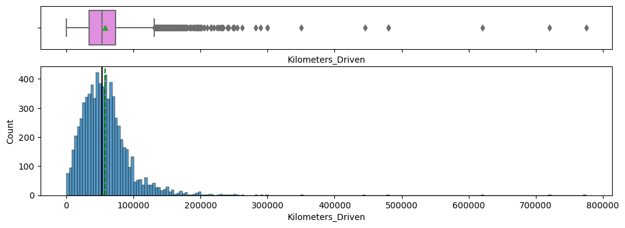

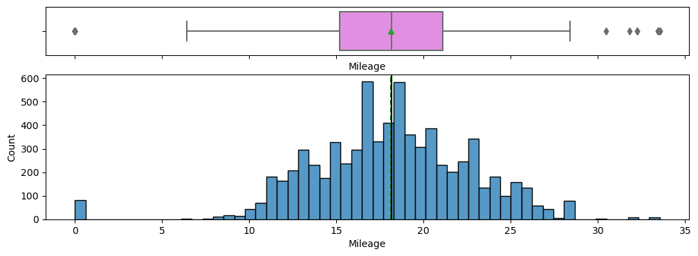

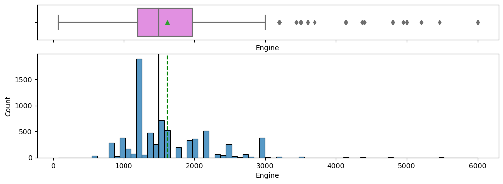

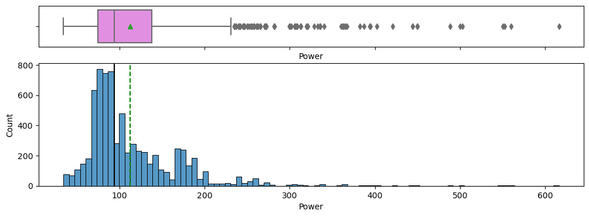

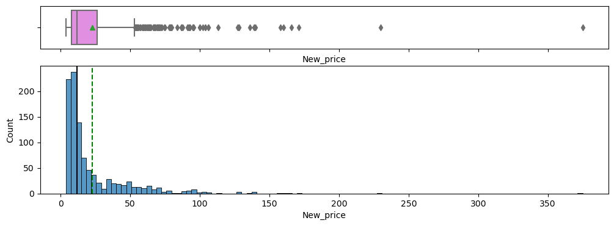

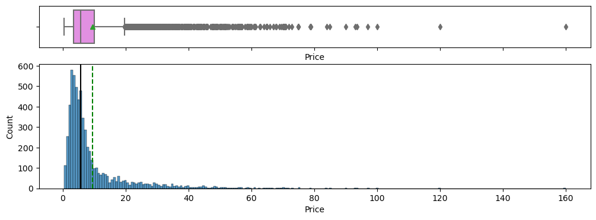

```python
num_col = list(data.select_dtypes("number").columns)
for col in num_col:
    if col != 'Seats' and col != 'Year':
        histogram_boxplot(data, col)
```

Observationn:

- 'Kilometer Driven' and 'Price' distributions are highly skewed with significant outliers. Log transformation will be required to bring the distribution close to normal

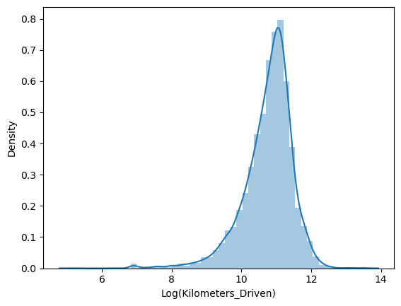

```python
# Log transformation of the feature 'Kilometers_Driven'
sns.distplot(np.log(data["Kilometers_Driven"]), axlabel = "Log(Kilometers_Driven)");
```

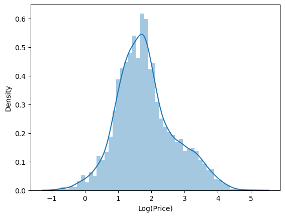

```python
# Log transformation of the feature 'Price'
sns.distplot(np.log(data["Price"]), axlabel = "Log(Price)");
```

Observation:

- Log transformation of 'Kilometer Driven' and 'Price' are close to normal. I'll add them to the dataframe as new features.

```python
data["kilometers_driven_log"] = np.log(data["Kilometers_Driven"])
data["Price_log"] = np.log(data["Price"])
```

### **Univariate Analysis - Categorical Variables**

```python
#Custom Function to create countplots for categorical variables.
#Custom Function indicates percentage for each category of a variable.
#Custom Function orders the bars in decreasing order of height/percentage.
#Custom Function takes in dataframe and column name as inputs.
def bar_perc(data, z):
    total = len(data[z]) # Length of the column.
    plt.figure(figsize = (20, 5)) #specify size of figure.
    ax = sns.countplot(data[z], palette = 'Paired',order = data[z].value_counts().index) #countplot
    for p in ax.patches:
        percentage = '{:.1f}%'.format(100 * p.get_height() / total) # Percentage of each class
        x = p.get_x() + p.get_width() / 2 - 0.05                    # Width of the plot
        y = p.get_y() + p.get_height()                              # Height of the plot
        ax.annotate(percentage, (x, y), size = 12)                  # Annotate the percentage
    plt.show()
```

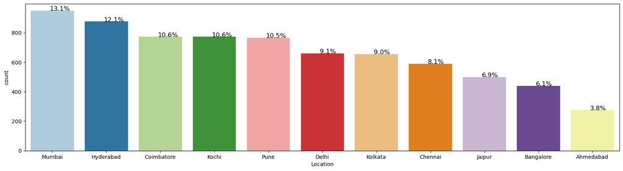

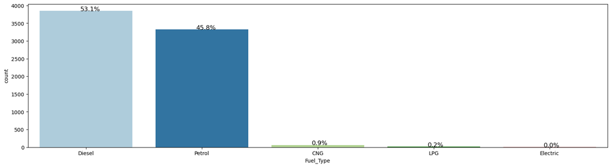

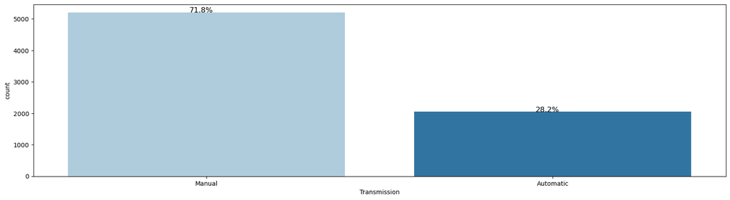

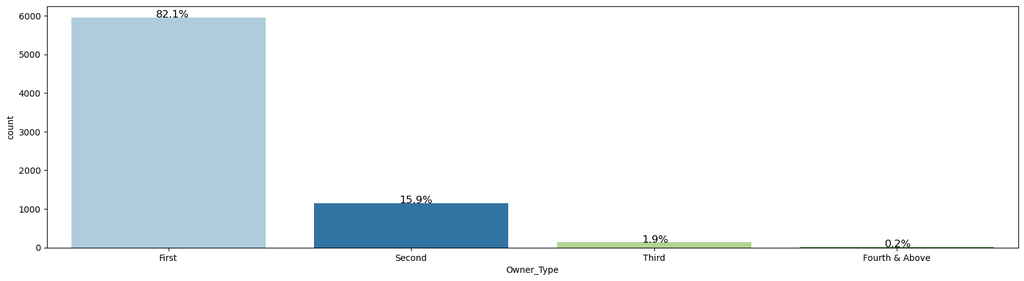

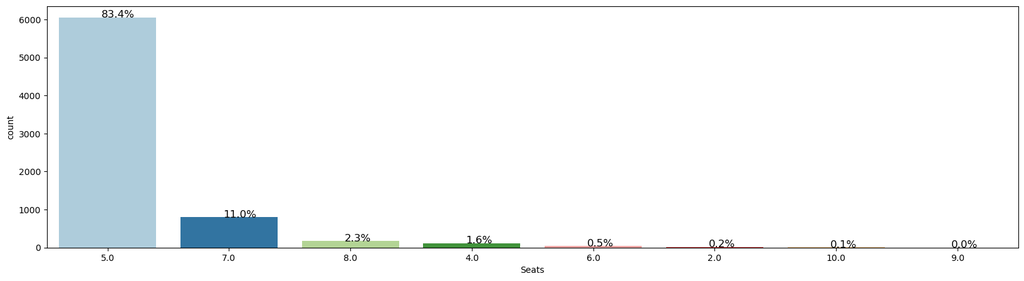

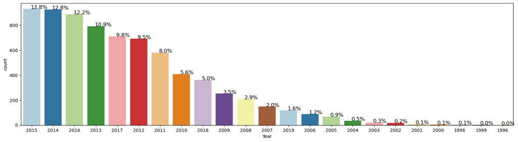

```python
cat_col = list(data.select_dtypes("object").columns)
cat_col.extend(['Seats', 'Year'])
for col in cat_col:
    if col != 'Name':
       bar_perc(data, col)
```

## **Bivariate Analysis**

### **1. Heat map**

Heatmap shows a 2D correlation matrix between two numerical features.

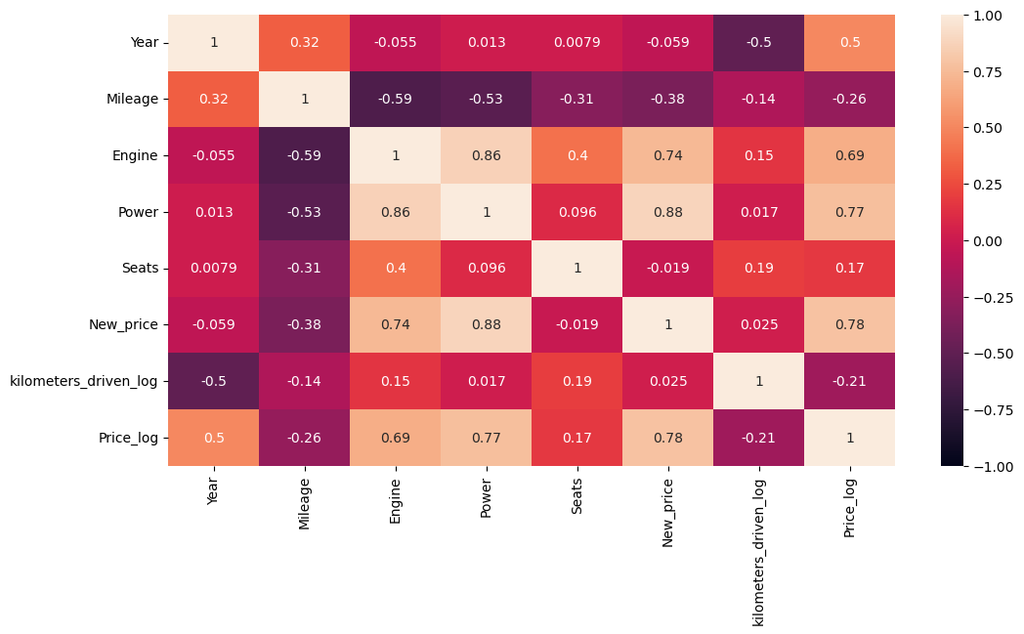

```python
plt.figure(figsize = (12, 6))
sns.heatmap(data.drop(["Kilometers_Driven","Price"],axis = 1).corr(), annot = True, vmin = -1, vmax = 1)
plt.show()
```

Observation:

- Target variable (price_log) has significant correlation with power, engine size, year and new_price. I'll keep an eye out for these variables while building the model.
- These independent variables also have some correlation among themselves. This is a sign of multicolinearity that needs to be addressed before a regression model is built

### **2. Scatter plot**

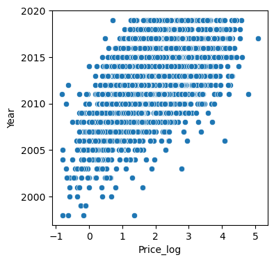

```python
plt.figure(figsize = (4, 4))
sns.scatterplot(x = 'Price_log', y = 'Year', data = data)
plt.show()
```

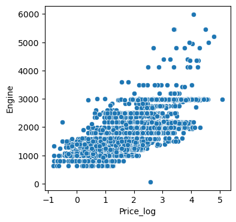

```python
plt.figure(figsize = (4, 4))
sns.scatterplot(x = 'Price_log', y = 'Engine', data = data)
plt.show()
```

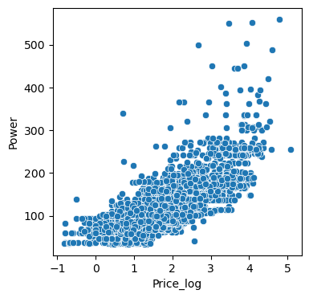

```python
plt.figure(figsize = (4, 4))
sns.scatterplot(x = 'Price_log', y = 'Power', data = data)
plt.show()
```

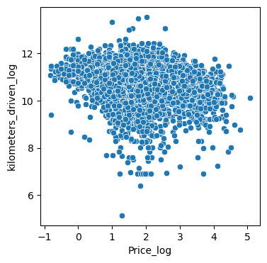

```python
plt.figure(figsize = (4, 4))
sns.scatterplot(x = 'Price_log', y = "kilometers_driven_log", data = data)
plt.show()
```

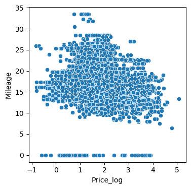

```python
plt.figure(figsize = (4, 4))
sns.scatterplot(x = 'Price_log', y = 'Mileage', data = data)
plt.show()
```

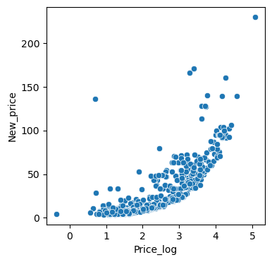

```python
plt.figure(figsize = (4, 4))
sns.scatterplot(x = 'Price_log', y = "New_price", data = data)
plt.show()
```

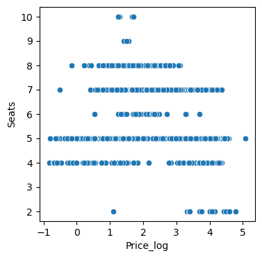

```python
plt.figure(figsize = (4, 4))
sns.scatterplot(x = 'Price_log', y = 'Seats', data = data)
plt.show()
```

Observation:

- Positive correlation apparent between target varibale (price_log) and year, engine size, power, new_price.
- Correlation not apparent with Seats, Mileage, kilometer_driven_log.
- This is an indication of variables to look out for in a regression model.